# R Notebook

# 11 March 2018

# DS 4100

# Assignment 11

Packages

```r
library(XML)
library(ggplot2)
library(magrittr)
library(yaml)
library(lubridate)
library(RCurl)
library(readxl)
library(BSDA)
library(forecast)
```

Importing data from excel file

```r
uffiData <- read_excel("uffidata.xlsx")
```

1. Are there outliers in the data set? If so, what is the appropriate action and how are they discovered? We’ll define outliers as any cases which are farther than 3 standard deviations from the mean. We can calculate how many standard deviations from the mean each case is, then investigate all cases that are more than 3 standard deviations from the mean.

```r
# First, creating a function to help calculate z-scores
get_zScores <- function(n) {
    # Function to calculate the Z-Score for each data point in a vector
    # Args: Numeric vector
    # Returns: Numeric vector representing the number of standard deviations from the mean for corresponding
    # elements in 'n'
    stdDev <- sd(n) # calculate the standard deviation of the data set
    mean <- mean(n) # calculate the mean
    zScore <- (n-mean)/stdDev # find how many standard deviations away each data point is
    return(zScore) # return vector of z-scores
}

# calculating the z-scores for each of our non-categorical variables
salePrice_zScore <- get_zScores(uffiData$`Sale Price`)
bsmntArea_zScore <- get_zScores(uffiData$`Bsmnt Fin_SF`)
lotArea_zScore <- get_zScores(uffiData$`Lot Area`)
livArea_zScore <- get_zScores(uffiData$`Living Area_SF`)
```

Now, we’ll find outliers. We choose to define “outlier” as any property with a sale price greater than three standard deviations from the mean. In practice, this means we will remove the three most expensive homes from our data set when performing statistical analyses. There may be meaningful information in the data we choose to exclude, but we will choose to focus on homes whose price falls into the specified ranged of +/- 3 standard deviations from the mean.

```r
# Any home with a sale price farther than "threshold" standard deviations from the mean will
# be considered an outlier
threshold <- 3
outliers_salePrice <- which(abs(salePrice_zScore) > threshold); outliers_salePrice
```

```
## [1] 40 60 94
```

```r
outliers_bsmntSF <- which(abs(bsmntArea_zScore) > threshold); outliers_bsmntSF
```

```
## integer(0)
```

```r
outliers_lotArea <- which(abs(lotArea_zScore) > threshold); outliers_lotArea
```

```
## integer(0)
```

```r
outliers_livArea <- which(abs(livArea_zScore) > threshold); outliers_livArea
```

```
## [1] 40 60
```

```r
# Combine list of outliers
outliers <- union(outliers_salePrice, union(outliers_bsmntSF, union(outliers_lotArea, outliers_livArea)))
outliers # viewing output
```

```
## [1] 40 60 94
```

```r
# New data frame to represent data with outliers removed
uffi_noOutlier <- uffiData[-outliers,]
colnames(uffi_noOutlier) <- c("Observation", "YearSold", "SalePrice", "UFFI_in", "BrickExt", "Age45",
                              "BasementArea", "LotArea", "EnclosedSpaces", "LivingArea", "CentralAir",
                              "Pool")
```

2. Using visual analysis of the sales price with a histogram, is the data normally distributed and thus amenable to parametric statistical analysis?

We’ll also calculate the log transform of the sale price, to see if this helps to normalize the data.

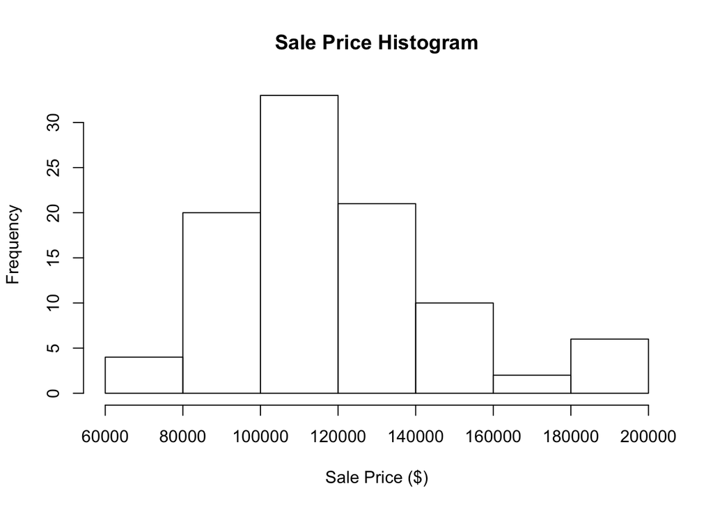

```r
# Calculating the logs
logSalePrice <- log(uffi_noOutlier$SalePrice)
# Adding the log transforms to our data frame
uffi_noOutlier <- cbind(uffi_noOutlier, logSalePrice)

# Visualizing with a histogram
# First, unaltered Sale Price
hist(uffi_noOutlier$SalePrice,
     xlab = "Sale Price ($)",
     ylab = "Frequency",
     main = "Sale Price Histogram")
```

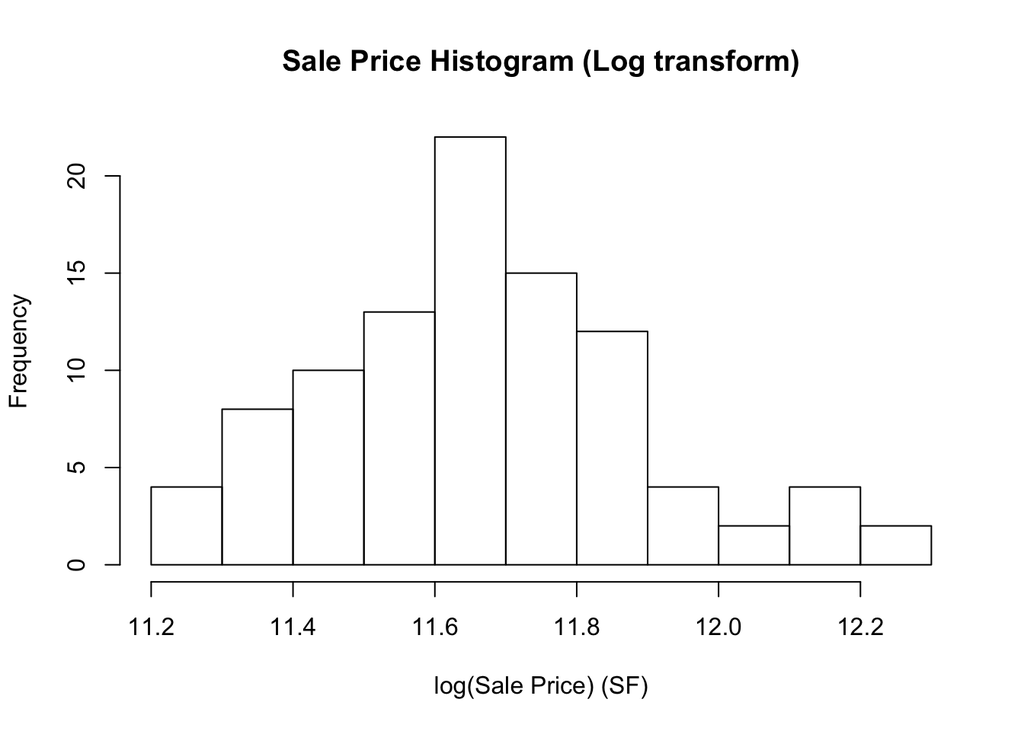

```r
# Next, log(Sale Price)
hist(uffi_noOutlier$logSalePrice,
     xlab = "log(Sale Price) (SF)",
     ylab = "Frequency",
     main = "Sale Price Histogram (Log transform)")
```

Analysis: Sales Price appears to roughly follow a normal distribution. Doing a log transform reduces the “bump” on the right side of the bell curve, but otherwise doesn’t seem to signficantly normalize the data. Therefore, for our analysis, we’ll assume that the Sale Price data is normally distributed.

3. Using a z-test, is the presence or absence of UFFI alone enough to predict the value of a residential property?

```r
# Let's separate the samples with and without uffi
uffi_yes <- uffi_noOutlier[which(uffi_noOutlier$UFFI_in == 1),] # cases with UFFI
uffi_no <- uffi_noOutlier[-which(uffi_noOutlier$UFFI_in == 1),] # cases without UFFI

# Performing a t-test
uffi_t.test <- t.test(x = uffi_yes$SalePrice, y = uffi_no$SalePrice); uffi_t.test
```

```
##
##  Welch Two Sample t-test
##
## data:  uffi_yes$SalePrice and uffi_no$SalePrice
## t = -2.0933, df = 34.612, p-value = 0.04372
## alternative hypothesis: true difference in means is not equal to 0
## 95 percent confidence interval:
##  -27777.7312   -420.0574
## sample estimates:
## mean of x mean of y
##  108647.7  122746.6
```

```r
# Performing a z-test
uffi_z.test <- z.test(x = uffi_yes$SalePrice,
                      y = uffi_no$SalePrice,
                      sigma.x = sd(uffi_yes$SalePrice),
                      sigma.y = sd(uffi_no$SalePrice)); uffi_z.test
```

```
##
##  Two-sample z-Test
##
## data:  uffi_yes$SalePrice and uffi_no$SalePrice
## z = -2.0933, p-value = 0.03632
## alternative hypothesis: true difference in means is not equal to 0
## 95 percent confidence interval:
##  -27299.8061   -897.9826
## sample estimates:
## mean of x mean of y
##  108647.7  122746.6
```

Based on a z-test, the presence of UFFI alone could potentially be used to predict the sales price of the home. The z-test compares the mean sales price of houses with and without UFFI, and attempts to determine if there is a statistically significant difference between them. Because the sample size is relatively small (~75 homes without UFFI and ~25 homes with UFFI), I think a t-test may be more appropriate in this case. Both tests returned p-values less than 0.05, but not by much.

4. Is UFFI a significant predictor variable of selling price when taken with the full set of variables available?

First, we’ll investigate the relationship between the independent variables and the Sale Price of homes. We’ll check to see if there is a positive or negative relationship, and whether the relationship is linear.

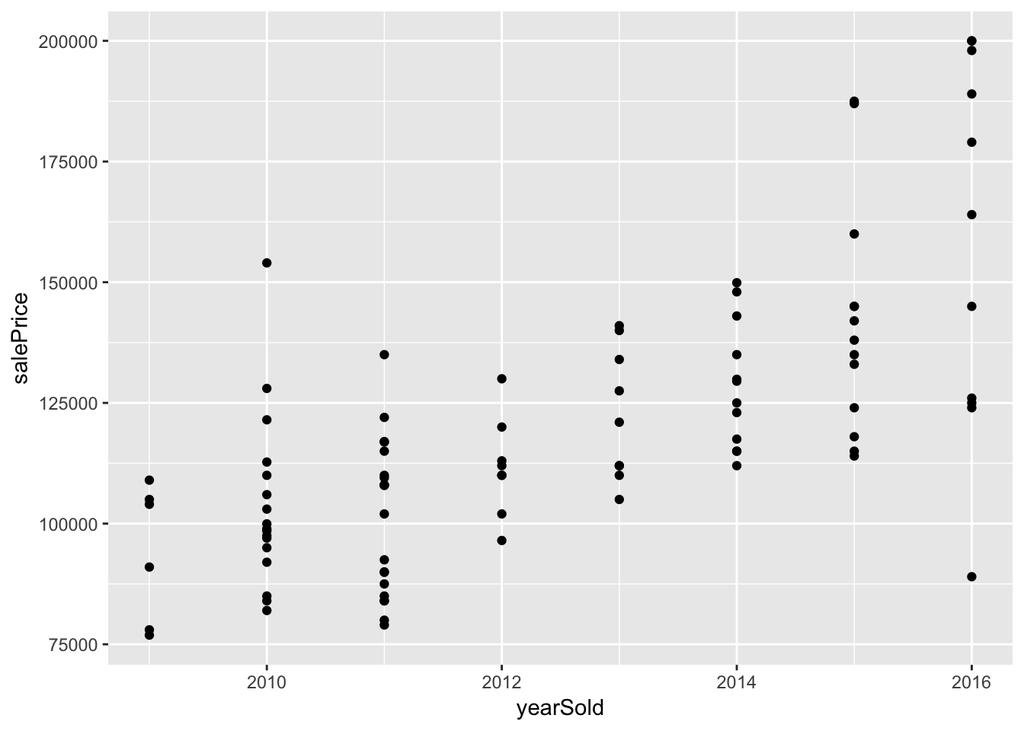

```r
salePrice <- uffi_noOutlier$SalePrice
yearSold <- uffi_noOutlier$YearSold
uffiIn <- uffi_noOutlier$UFFI_in
brickExt <- uffi_noOutlier$BrickExt
age45 <- uffi_noOutlier$Age45
basementSF <- uffi_noOutlier$BasementArea
lotArea <- uffi_noOutlier$LotArea
encSpace <- uffi_noOutlier$EnclosedSpaces
livingSF <- uffi_noOutlier$LivingArea
centralAir <- uffi_noOutlier$CentralAir
pool <- uffi_noOutlier$Pool

ggplot(uffi_noOutlier, aes(yearSold, salePrice)) + geom_point()
```

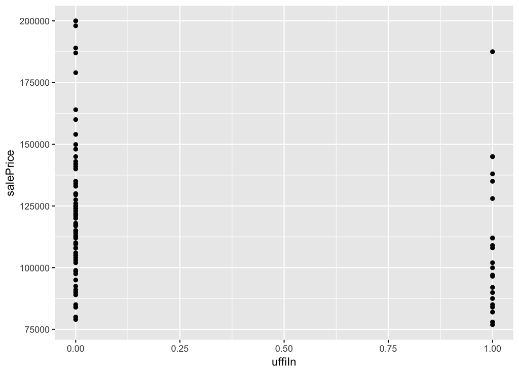

```r
ggplot(uffi_noOutlier, aes(uffiIn, salePrice)) + geom_point()
```

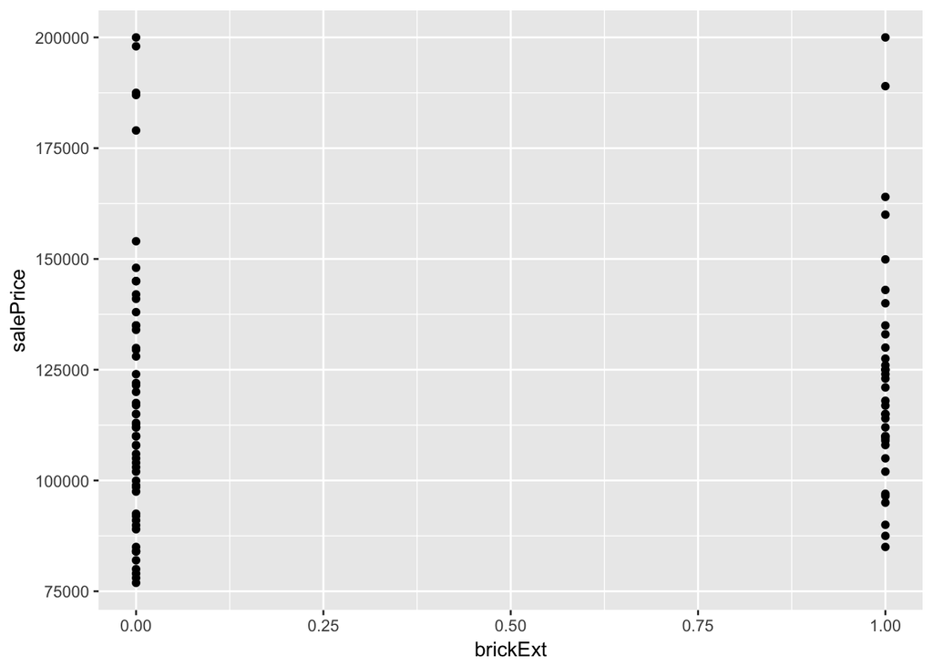

```r
ggplot(uffi_noOutlier, aes(brickExt, salePrice)) + geom_point()
```

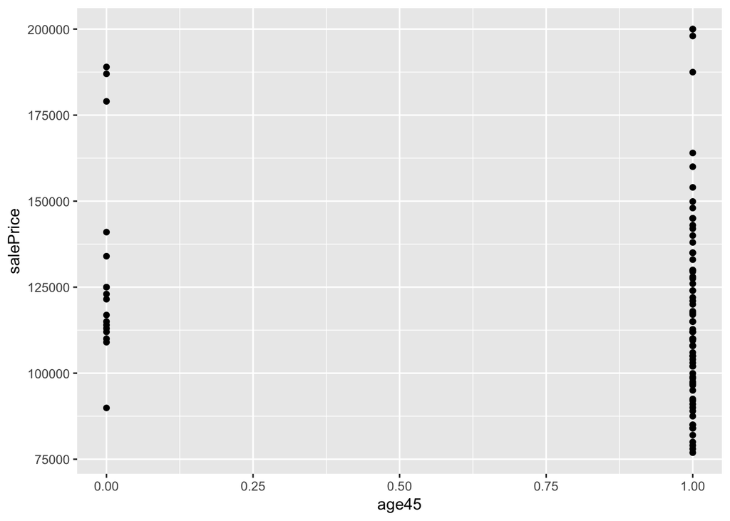

```r
ggplot(uffi_noOutlier, aes(age45, salePrice)) + geom_point()
```

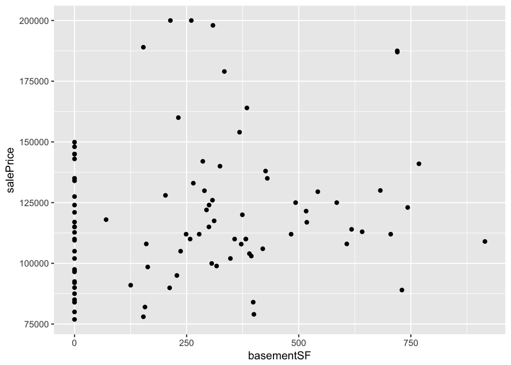

```r
ggplot(uffi_noOutlier, aes(basementSF, salePrice)) + geom_point()
```

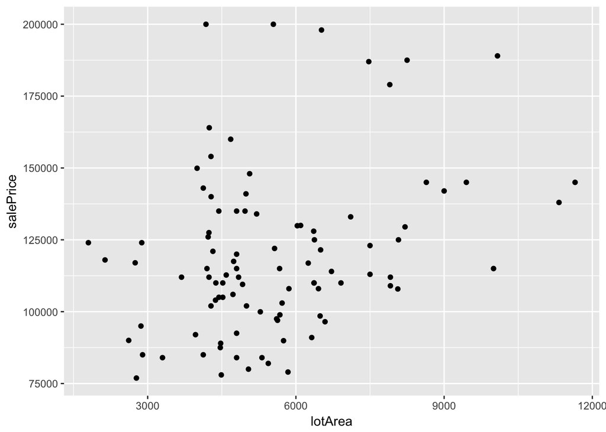

```r
ggplot(uffi_noOutlier, aes(lotArea, salePrice)) + geom_point()
```

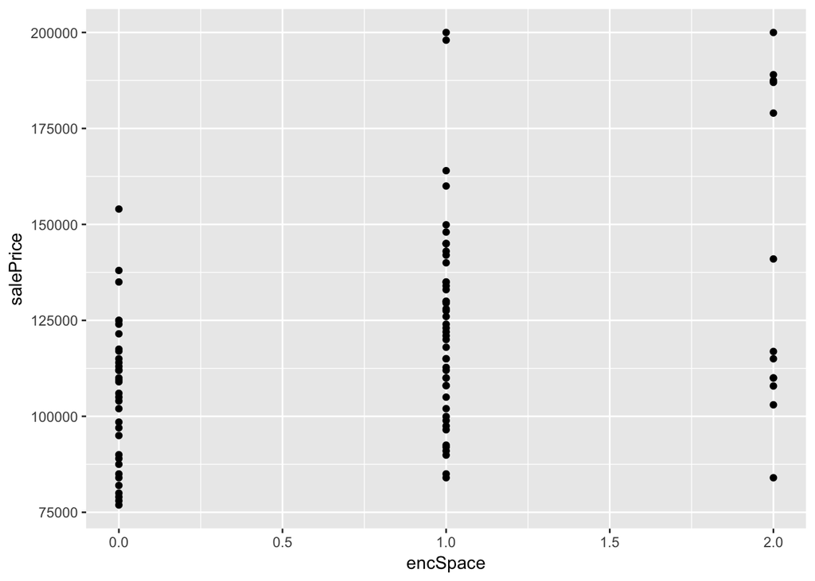

```r
ggplot(uffi_noOutlier, aes(encSpace, salePrice)) + geom_point()
```

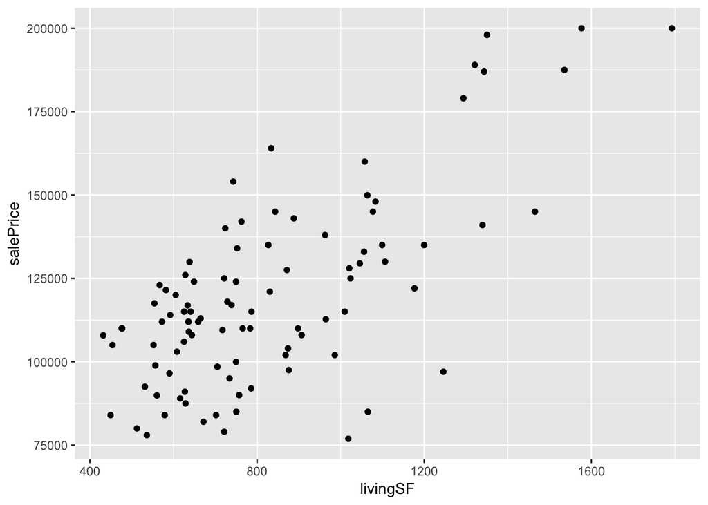

```r
ggplot(uffi_noOutlier, aes(livingSF, salePrice)) + geom_point()
```

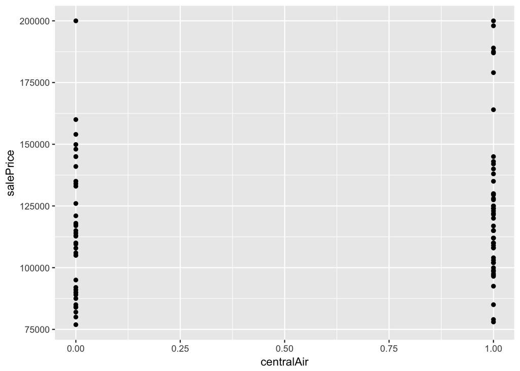

```r
ggplot(uffi_noOutlier, aes(centralAir, salePrice)) + geom_point()
```

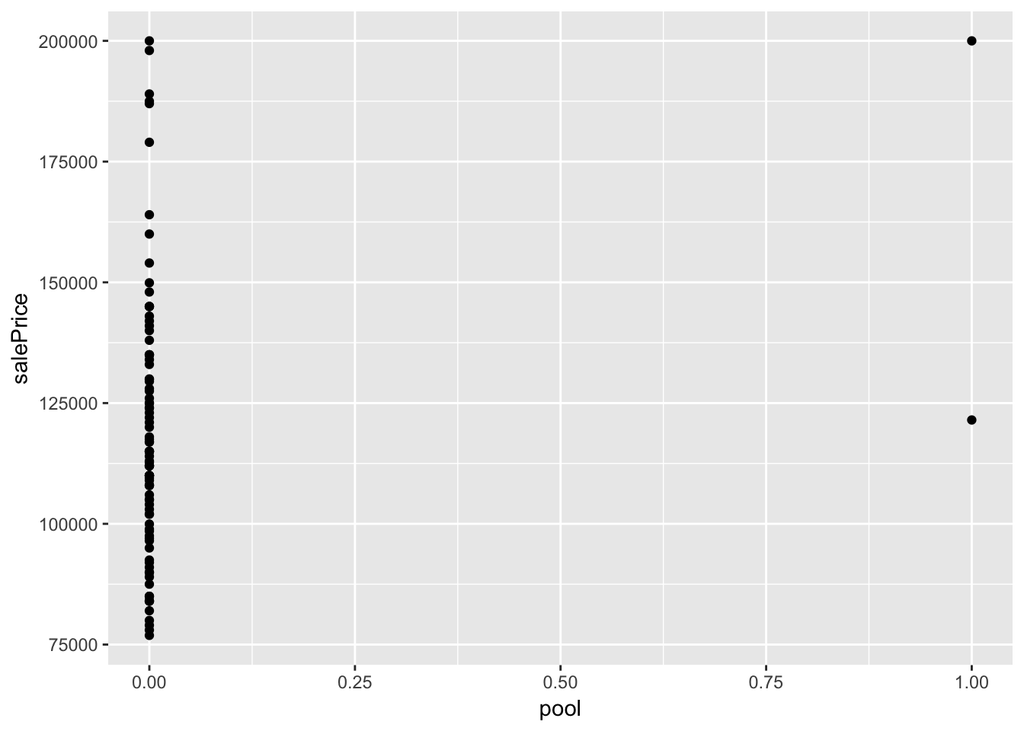

```r
ggplot(uffi_noOutlier, aes(pool, salePrice)) + geom_point()
```

The best candidates for our linear regression model appear to be living area and year sold. Enclosed spaces also seems to display a linear trend. All three of these independent variables display a positive relationship with the Sale Price. UFFI appears to display a slight negative correlation, but we cannot say whether this effect will be significant when taken with the other variables.

Now that we’ve established normality, excluded outliers, and identified several dependent variables that seem to be correlated with the sales price, we will create a multiple regression model.

```r
# First, creating linear regression model
model <- lm(SalePrice ~. -SalePrice -Observation -logSalePrice, data = uffi_noOutlier)
# We include all variables from our data frame except for SalePrice, Observation, and logSalePrice
summary(model)
```

```
##
## Call:
## lm(formula = SalePrice ~ . - SalePrice - Observation - logSalePrice,
##     data = uffi_noOutlier)
##
## Residuals:
##    Min     1Q Median     3Q    Max
## -38718  -8500    257   7832  57124
##
## Coefficients:
##                  Estimate Std. Error t value Pr(>|t|)
## (Intercept)    -1.081e+07  1.581e+06  -6.838 1.15e-09 ***
## YearSold        5.408e+03  7.875e+02   6.867 1.01e-09 ***
## UFFI_in        -6.885e+03  3.747e+03  -1.837   0.0697 .
## BrickExt        1.463e+03  3.347e+03   0.437   0.6632
## Age45          -1.545e+03  4.821e+03  -0.320   0.7494
## BasementArea    1.177e+01  7.401e+00   1.590   0.1155
## LotArea         7.199e-01  9.532e-01   0.755   0.4522
## EnclosedSpaces  6.119e+03  2.383e+03   2.567   0.0120 *
## LivingArea      4.725e+01  6.112e+00   7.730 1.97e-11 ***
## CentralAir      2.752e+03  3.197e+03   0.861   0.3917
## Pool            1.690e+04  1.072e+04   1.576   0.1187
## ---
## Signif. codes:  0 '***' 0.001 '**' 0.01 '*' 0.05 '.' 0.1 ' ' 1
##
## Residual standard error: 14320 on 85 degrees of freedom
## Multiple R-squared:  0.7709, Adjusted R-squared:  0.744
## F-statistic: 28.61 on 10 and 85 DF,  p-value: < 2.2e-16
```

5. What is the ideal multiple regression model for predicting home prices in this data set? Provide a detailed analysis of the model, including Adjusted R-Squared, MAD, and p-values of principal components.

After first including all variables, we will use backward elimination to remove independent variables from our model which have p-values greater than 0.05.

First, we remove Age45 variable, which has the highest p-value

```r
model_step <- lm(SalePrice ~.
                 -SalePrice
                 -Observation
                 -logSalePrice
                 -Age45,
                 data = uffi_noOutlier)
summary(model_step)
```

```
##
## Call:
## lm(formula = SalePrice ~ . - SalePrice - Observation - logSalePrice -
##     Age45, data = uffi_noOutlier)
##
## Residuals:
##    Min     1Q Median     3Q    Max
## -39267  -8755     80   8073  56890
##
## Coefficients:
##                  Estimate Std. Error t value Pr(>|t|)
## (Intercept)    -1.079e+07  1.572e+06  -6.867 9.70e-10 ***
## YearSold        5.396e+03  7.825e+02   6.896 8.49e-10 ***
## UFFI_in        -7.012e+03  3.707e+03  -1.891   0.0619 .
## BrickExt        1.805e+03  3.155e+03   0.572   0.5686
## BasementArea    1.273e+01  6.731e+00   1.891   0.0619 .
## LotArea         8.260e-01  8.891e-01   0.929   0.3554
## EnclosedSpaces  6.104e+03  2.371e+03   2.575   0.0117 *
## LivingArea      4.710e+01  6.062e+00   7.769 1.55e-11 ***
## CentralAir      2.679e+03  3.172e+03   0.845   0.4006
## Pool            1.739e+04  1.056e+04   1.647   0.1032
## ---
## Signif. codes:  0 '***' 0.001 '**' 0.01 '*' 0.05 '.' 0.1 ' ' 1
##
## Residual standard error: 14250 on 86 degrees of freedom
## Multiple R-squared:  0.7706, Adjusted R-squared:  0.7466
## F-statistic: 32.11 on 9 and 86 DF,  p-value: < 2.2e-16
```

We remove BrickExt predictor variable

```r
model_step <- lm(SalePrice ~.
                 -SalePrice
                 -Observation
                 -logSalePrice
                 -Age45
                 -BrickExt,
                 data = uffi_noOutlier)
summary(model_step)
```

```
##
## Call:
## lm(formula = SalePrice ~ . - SalePrice - Observation - logSalePrice -
##     Age45 - BrickExt, data = uffi_noOutlier)
##
## Residuals:
##    Min     1Q Median     3Q    Max
## -40377  -8526    534   7778  56294
##
## Coefficients:
##                  Estimate Std. Error t value Pr(>|t|)
## (Intercept)    -1.100e+07  1.524e+06  -7.215 1.89e-10 ***
## YearSold        5.499e+03  7.587e+02   7.247 1.63e-10 ***
## UFFI_in        -6.962e+03  3.692e+03  -1.886   0.0626 .
## BasementArea    1.251e+01  6.693e+00   1.869   0.0650 .
## LotArea         7.678e-01  8.798e-01   0.873   0.3852
## EnclosedSpaces  5.888e+03  2.331e+03   2.526   0.0134 *
## LivingArea      4.717e+01  6.037e+00   7.813 1.19e-11 ***
## CentralAir      2.751e+03  3.157e+03   0.871   0.3860
## Pool            1.674e+04  1.046e+04   1.601   0.1130
## ---
## Signif. codes:  0 '***' 0.001 '**' 0.01 '*' 0.05 '.' 0.1 ' ' 1
##
## Residual standard error: 14190 on 87 degrees of freedom
## Multiple R-squared:  0.7698, Adjusted R-squared:  0.7486
## F-statistic: 36.36 on 8 and 87 DF,  p-value: < 2.2e-16
```

We remove CentralAir predictor variable

```r
model_step <- lm(SalePrice ~.
                 -SalePrice
                 -Observation
                 -logSalePrice
                 -Age45
                 -BrickExt
                 -CentralAir,
                 data = uffi_noOutlier)
summary(model_step)
```

```
##
## Call:
## lm(formula = SalePrice ~ . - SalePrice - Observation - logSalePrice -
##     Age45 - BrickExt - CentralAir, data = uffi_noOutlier)
##
## Residuals:
##    Min     1Q Median     3Q    Max
## -42203  -8943    309   8757  54609
##
## Coefficients:
##                  Estimate Std. Error t value Pr(>|t|)
## (Intercept)    -1.087e+07  1.515e+06  -7.174 2.18e-10 ***
## YearSold        5.434e+03  7.541e+02   7.206 1.88e-10 ***
## UFFI_in        -7.149e+03  3.681e+03  -1.942   0.0553 .
## BasementArea    1.408e+01  6.438e+00   2.187   0.0314 *
## LotArea         9.007e-01  8.653e-01   1.041   0.3008
## EnclosedSpaces  5.948e+03  2.327e+03   2.556   0.0123 *
## LivingArea      4.770e+01  5.999e+00   7.952 5.82e-12 ***
## Pool            1.606e+04  1.041e+04   1.543   0.1265
## ---
## Signif. codes:  0 '***' 0.001 '**' 0.01 '*' 0.05 '.' 0.1 ' ' 1
##
## Residual standard error: 14170 on 88 degrees of freedom
## Multiple R-squared:  0.7678, Adjusted R-squared:  0.7493
## F-statistic: 41.56 on 7 and 88 DF,  p-value: < 2.2e-16
```

We remove LotArea predictor variable

```r
model_step <- lm(SalePrice ~.
                 -SalePrice
                 -Observation
                 -logSalePrice
                 -Age45
                 -BrickExt
                 -CentralAir
                 -LotArea,
                 data = uffi_noOutlier)
summary(model_step)
```

```
##
## Call:
## lm(formula = SalePrice ~ . - SalePrice - Observation - logSalePrice -
##     Age45 - BrickExt - CentralAir - LotArea, data = uffi_noOutlier)
##
## Residuals:
##    Min     1Q Median     3Q    Max
## -44195  -9296   1013   8490  54111
##
## Coefficients:
##                  Estimate Std. Error t value Pr(>|t|)
## (Intercept)    -1.120e+07  1.481e+06  -7.565 3.37e-11 ***
## YearSold        5.603e+03  7.369e+02   7.603 2.81e-11 ***
## UFFI_in        -6.247e+03  3.579e+03  -1.746  0.08433 .
## BasementArea    1.610e+01  6.140e+00   2.622  0.01027 *
## EnclosedSpaces  6.247e+03  2.310e+03   2.704  0.00821 **
## LivingArea      4.827e+01  5.976e+00   8.077 3.02e-12 ***
## Pool            1.603e+04  1.042e+04   1.539  0.12733
## ---
## Signif. codes:  0 '***' 0.001 '**' 0.01 '*' 0.05 '.' 0.1 ' ' 1
##
## Residual standard error: 14180 on 89 degrees of freedom
## Multiple R-squared:  0.7649, Adjusted R-squared:  0.7491
## F-statistic: 48.26 on 6 and 89 DF,  p-value: < 2.2e-16
```

We remove Pool predictor variable

```r
model_step <- lm(SalePrice ~.
                 -SalePrice
                 -Observation
                 -logSalePrice
                 -Age45
                 -BrickExt
                 -CentralAir
                 -LotArea
                 -Pool,
                 data = uffi_noOutlier)
summary(model_step)
```

```
##
## Call:
## lm(formula = SalePrice ~ . - SalePrice - Observation - logSalePrice -
##     Age45 - BrickExt - CentralAir - LotArea - Pool, data = uffi_noOutlier)
##
## Residuals:
##    Min     1Q Median     3Q    Max
## -44419  -9661    949   8043  53490
##
## Coefficients:
##                  Estimate Std. Error t value Pr(>|t|)
## (Intercept)    -1.105e+07  1.489e+06  -7.421 6.27e-11 ***
## YearSold        5.525e+03  7.407e+02   7.458 5.25e-11 ***
## UFFI_in        -6.768e+03  3.590e+03  -1.885  0.06262 .
## BasementArea    1.695e+01  6.161e+00   2.751  0.00718 **
## EnclosedSpaces  6.206e+03  2.328e+03   2.666  0.00909 **
## LivingArea      5.013e+01  5.898e+00   8.500 3.77e-13 ***
## ---
## Signif. codes:  0 '***' 0.001 '**' 0.01 '*' 0.05 '.' 0.1 ' ' 1
##
## Residual standard error: 14280 on 90 degrees of freedom
## Multiple R-squared:  0.7586, Adjusted R-squared:  0.7452
## F-statistic: 56.58 on 5 and 90 DF,  p-value: < 2.2e-16
```

We remove UFFI predictor variable

```r
model_step <- lm(SalePrice ~.
                 -SalePrice
                 -Observation
                 -logSalePrice
                 -Age45
                 -BrickExt
                 -CentralAir
                 -LotArea
                 -Pool
                 -UFFI_in,
                 data = uffi_noOutlier)
summary(model_step)
```

```
##
## Call:
## lm(formula = SalePrice ~ . - SalePrice - Observation - logSalePrice -
##     Age45 - BrickExt - CentralAir - LotArea - Pool - UFFI_in,
##     data = uffi_noOutlier)
##
## Residuals:
##    Min     1Q Median     3Q    Max
## -43850  -8941    377   8133  56013
##
## Coefficients:
##                  Estimate Std. Error t value Pr(>|t|)
## (Intercept)    -1.161e+07  1.479e+06  -7.855 7.65e-12 ***
## YearSold        5.805e+03  7.357e+02   7.891 6.45e-12 ***
## BasementArea    1.721e+01  6.246e+00   2.755  0.00709 **
## EnclosedSpaces  6.762e+03  2.341e+03   2.888  0.00484 **
## LivingArea      4.873e+01  5.933e+00   8.215 1.37e-12 ***
## ---
## Signif. codes:  0 '***' 0.001 '**' 0.01 '*' 0.05 '.' 0.1 ' ' 1
##
## Residual standard error: 14480 on 91 degrees of freedom
## Multiple R-squared:  0.7491, Adjusted R-squared:  0.7381
## F-statistic: 67.93 on 4 and 91 DF,  p-value: < 2.2e-16
```

All of the remaining variables have p-values < 0.05. Therefore, our ideal model is:

```r
# Creating ideal model
model_ideal <- lm(SalePrice ~ YearSold + BasementArea + EnclosedSpaces + LivingArea, data = uffi_noOutlier)
summary(model_ideal) # viewing model details
```

```
##
## Call:
## lm(formula = SalePrice ~ YearSold + BasementArea + EnclosedSpaces +
##     LivingArea, data = uffi_noOutlier)
##
## Residuals:
##    Min     1Q Median     3Q    Max
## -43850  -8941    377   8133  56013
##
## Coefficients:
##                  Estimate Std. Error t value Pr(>|t|)
## (Intercept)    -1.161e+07  1.479e+06  -7.855 7.65e-12 ***
## YearSold        5.805e+03  7.357e+02   7.891 6.45e-12 ***
## BasementArea    1.721e+01  6.246e+00   2.755  0.00709 **
## EnclosedSpaces  6.762e+03  2.341e+03   2.888  0.00484 **
## LivingArea      4.873e+01  5.933e+00   8.215 1.37e-12 ***
## ---
## Signif. codes:  0 '***' 0.001 '**' 0.01 '*' 0.05 '.' 0.1 ' ' 1
##
## Residual standard error: 14480 on 91 degrees of freedom
## Multiple R-squared:  0.7491, Adjusted R-squared:  0.7381
## F-statistic: 67.93 on 4 and 91 DF,  p-value: < 2.2e-16
```

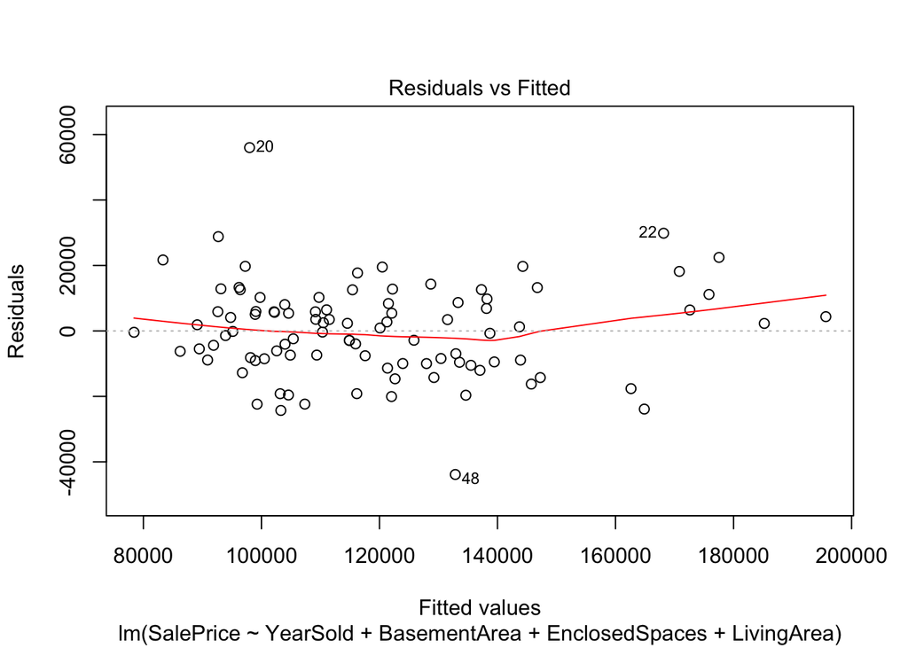

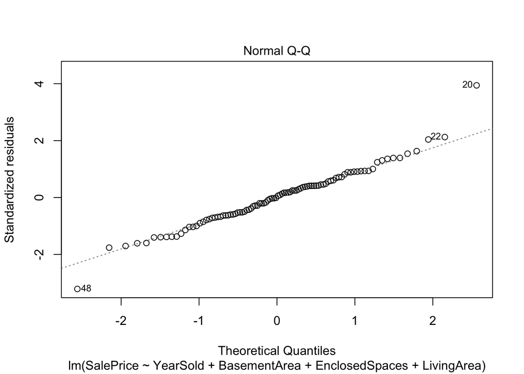

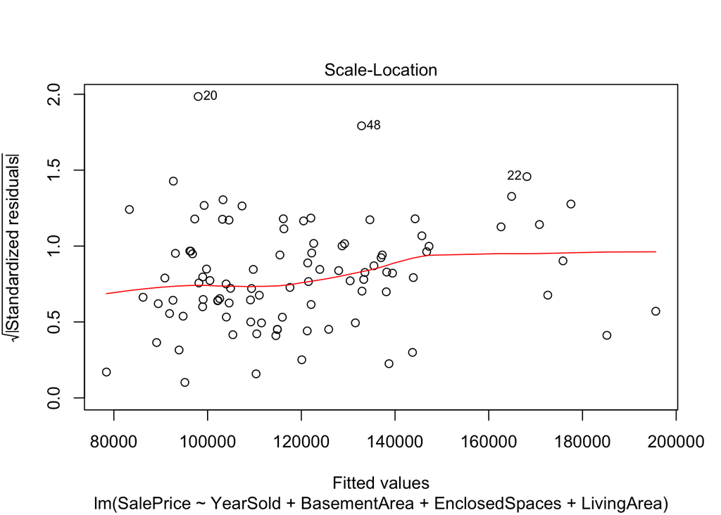

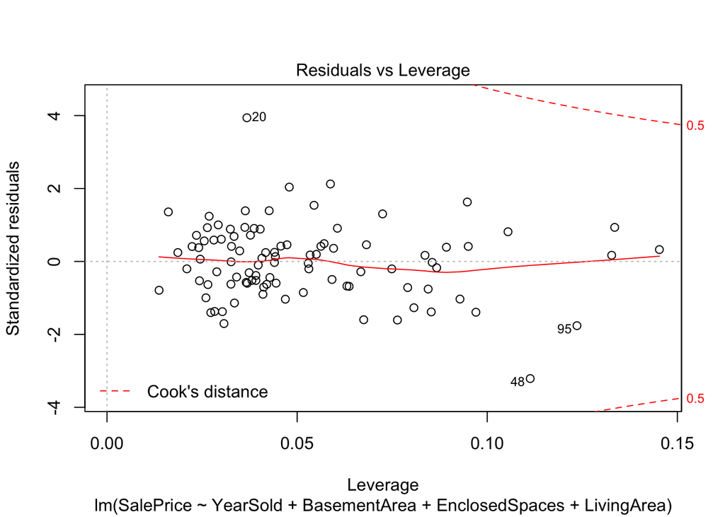

```r
plot(model_ideal) # plotting
```

```r
# Next, we'll calculate the MAD ("Mean absolute deviation")
mean(abs(residuals(model_ideal))) # find the mean of the absolute value of residuals in the model
```

```
## [1] 10880.88
```

The adjusted R-squared for the ideal model is 0.7381, indicating that about 74 percent of the variability in the dependent variable can be attributed to the independent variable.

The MAD for the model is about $11,000, indicating that on average, a given predicted value from our model differs from the corresponding actual value by this amount.

The Residuals vs. Fitted plot doesn’t seem to display any distinct pattern; however, we note that the model did miss several cases by a large amount. We also note that the 7 highest fitted values all had positive residuals. The sample size is relatively small and therefore it is difficult to draw meaningful conclusions from this observation, but this trend may reveal a characteristic of housing markets, where homes on the upper end of the price spectrum require a different model than lower-priced homes (i.e. these houses belong to a different “cluster”).

The Normal Q-Q plot shows that actual and predicted values appear to fall into a similar distribution, with the plotted values generally following the 45º line. However, for the bottom and top quantiles, we note that the plotted values tail off, indicating that the actual data may have “fatter tails” than our model predicts.

The p-values for YearSold and LivingArea are both essentially 0, indicating that they are both likely predictors of SalePrice. EnclosedSpaces and BasementArea have higher p-values, still less than 0.01, indicating we are less confident about their significance, but still consider them to be statistically meaningful predictors of SalePrice.

6. On average, how do we expect UFFI will change the value of a property?

```r
# Adding uffiIn as an independent variable to our ideal multiple regression model
model_uffi <- lm(SalePrice ~ YearSold + BasementArea + LivingArea + EnclosedSpaces + UFFI_in,
                 data = uffi_noOutlier)
summary(model_uffi)
```

```
##
## Call:
## lm(formula = SalePrice ~ YearSold + BasementArea + LivingArea +
##     EnclosedSpaces + UFFI_in, data = uffi_noOutlier)
##
## Residuals:
##    Min     1Q Median     3Q    Max
## -44419  -9661    949   8043  53490
##
## Coefficients:
##                  Estimate Std. Error t value Pr(>|t|)
## (Intercept)    -1.105e+07  1.489e+06  -7.421 6.27e-11 ***
## YearSold        5.525e+03  7.407e+02   7.458 5.25e-11 ***
## BasementArea    1.695e+01  6.161e+00   2.751  0.00718 **
## LivingArea      5.013e+01  5.898e+00   8.500 3.77e-13 ***
## EnclosedSpaces  6.206e+03  2.328e+03   2.666  0.00909 **
## UFFI_in        -6.768e+03  3.590e+03  -1.885  0.06262 .
## ---
## Signif. codes:  0 '***' 0.001 '**' 0.01 '*' 0.05 '.' 0.1 ' ' 1
##
## Residual standard error: 14280 on 90 degrees of freedom
## Multiple R-squared:  0.7586, Adjusted R-squared:  0.7452
## F-statistic: 56.58 on 5 and 90 DF,  p-value: < 2.2e-16
```

The p-value for UFFI is greater than our threshold of 0.05, indicating that we don’t believe UFFI is a stastically signficant predictor. Keeping this in mind, we add UFFI to our multiple regression model to estimate the effect it might have on the sale price. According to our model, we expect the presence of UFFI to decrease the value of a home by almost $7,000 (with a standard error of about $3,500).

7. If the home in question is older than 45 years old, doesn’t have a finished basement, has a lot area of 5000 square feet, has a brick exterior, 2 enclosed parking spaces, 1700 square feet of living space, central air, and no pool, what is its predicted value and what are the 95% confidence intervals of this home with UFFI and without UFFI?

Based on earlier analysis, we have identified several meaningful predictors for the salePrice of a home: year sold, living area, basement area, and enclosed parking spaces. Therefore, when making predictions, we will ignore other variables.

```r
# First creating our ideal regression model (derived above)
model_ideal <- lm(SalePrice ~ YearSold + BasementArea + EnclosedSpaces + LivingArea, data = uffi_noOutlier)

# wrapping the parameters inside of a data frame
house_data <- data.frame(YearSold = 2012, LivingArea = 1700, EnclosedSpaces = 2, BasementArea = 0)

predict(model_ideal, house_data, interval = "predict") # applying the model
```

```
##        fit      lwr      upr
## 1 163423.9 132408.9 194438.9
```

Now, we will introduce UFFI, even though we have decided to exclude it from our ideal model.

```r
# Including UFFI in our model
model_uffi <- lm(SalePrice ~ YearSold + BasementArea + LivingArea + EnclosedSpaces + UFFI_in,
                 data = uffi_noOutlier)

# wrapping the parameters inside of a data frame (no UFFI)
house_data1 <- data.frame(YearSold = 2016, LivingArea = 1700, EnclosedSpaces = 2,
                          BasementArea = 0, UFFI_in = 0)
noUFFI_pred <- predict(model_uffi, house_data1, interval = "predict") # applying the model
noUFFI_pred # viewing results
```

```
##        fit      lwr      upr
## 1 187801.4 157514.7 218088.1
```

```r
# wrapping the parameters inside of a data frame (yes UFFI)
house_data2 <- data.frame(YearSold = 2016, LivingArea = 1700, EnclosedSpaces = 2,
                          BasementArea = 0, UFFI_in = 1)
yesUFFI_pred <- predict(model_uffi, house_data2, interval = "predict") # applying the model
yesUFFI_pred # viewing results
```

```
##        fit      lwr      upr
## 1 181033.7 150199.3 211868.1
```

First, let’s derive the average sale price data

```r
year = 2009:2016 # Years corresponding to our data
AvgPrice = vector(mode = 'numeric', length = length(year))

for (year in 2009:2016) { # for each year
    # compute the average price of homes
    AvgPrice[year-2008] <- mean(uffi_noOutlier$SalePrice[which(uffi_noOutlier$YearSold == year)])
}
names(AvgPrice) <- c(2009, 2010, 2011, 2012, 2013, 2014, 2015, 2016) # naming elements of the vector
AvgPrice # outputting the average price for each year
```

```
##      2009      2010      2011      2012      2013      2014      2015
##  93983.33 103829.41 101160.00 111687.50 122500.00 128566.67 141807.69
##      2016
## 158090.91
```

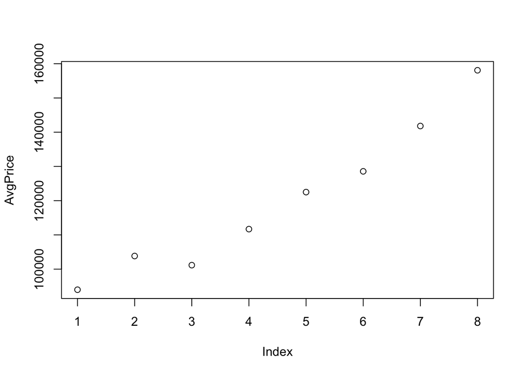

```r
plot(AvgPrice) # plotting
```

Next, weighted moving average model of the form:

```r
# The model has the below equation:
# Yt = 5*Y(t-1) + 3*Y(t-2) + 2*Y(t-3)
a = 5 # weight for most recent year
b = 3 # weight for second most recent year
c = 2 # weight for third most recent year

wma <- function(year) {
    # Function forecasts the average sales in a given year based on three most recent years
    # Args: year to be forecasted
    # Returns: estimated average sale price
    # Note this function is only valid for input arguments 2012 to 2017
    i = year-2008 # normalizing the indexing to compare to AvgPrice
    pred <- (a * AvgPrice[i-1] + b * AvgPrice[i-2] + c * AvgPrice[i-3]) / (a + b + c) # calculating forecast
    names(pred) <- year # naming according to input
    return(pred) # returning the prediction
}

pred2009 <- AvgPrice[1] # We'll artificially set the first "prediction" to match the actual
pred2010 <- AvgPrice[1] # Model's prediction for 2010; same as 2009
names(pred2010) <- 2010 # naming the prediction
pred2011 <- (a * AvgPrice[2] + b * AvgPrice[1]) / (a + b) # Model's prediction for 2011
names(pred2011) <- 2011 # naming the prediction
preds <- c(pred2009, pred2010, pred2011, sapply(2012:2016, wma)) # combining with predictions for 2012-2016

# Next, a function to help with calculating the MSE
diffSqr <- function(i) {
    # This function calculates the difference between actual and forecasted value,
    # then squares the result
    # Args: index of value to calculate
    # Returns: numeric, representing the squared difference between the two values
    return((AvgPrice[i] - preds[i])^2)
}

MSE_wma <- sum(sapply(1:length(AvgPrice), diffSqr)) / length(AvgPrice)
MSE_wma # outputting results
```

```
## [1] 196258883
```

Exponential Smoothing

```r
preds <- numeric(length = 8)
preds[1] <- AvgPrice[1] # seed model by setting first prediction equal to actual
for (i in 2:8) { # we need to find 7 more predictions
    preds[i] <- preds[i-1] + a * (AvgPrice[i-1] - preds[i-1]) # exponential smoothing eqn
}
MSE_exp <- sum(sapply(1:length(AvgPrice), diffSqr)) / length(AvgPrice)
MSE_exp # outputting results
```

```
## [1] 2.715095e+14
```

Linear Regression time series

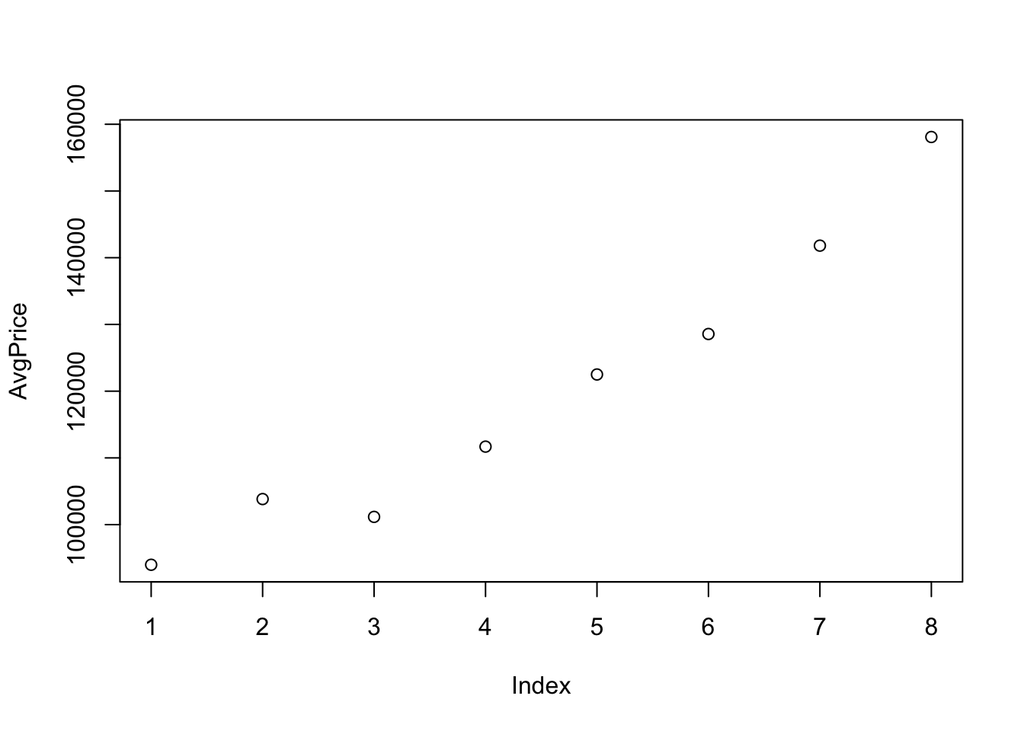

```r
plot(AvgPrice) # relationship appears linear, with positive correlation
```

```r
year <- seq(2009:2016) + 2008 # independent variable
model <- lm(AvgPrice ~ year) # creating model
summary(model)
```

```
##
## Call:
## lm(formula = AvgPrice ~ year)
##
## Residuals:
##    Min     1Q Median     3Q    Max
##  -5978  -4296  -1115   4551   7401
##
## Coefficients:
##               Estimate Std. Error t value Pr(>|t|)
## (Intercept) -1.741e+07  1.708e+06  -10.19  5.2e-05 ***
## year         8.710e+03  8.489e+02   10.26  5.0e-05 ***
## ---
## Signif. codes:  0 '***' 0.001 '**' 0.01 '*' 0.05 '.' 0.1 ' ' 1
##
## Residual standard error: 5501 on 6 degrees of freedom
## Multiple R-squared:  0.9461, Adjusted R-squared:  0.9371
## F-statistic: 105.3 on 1 and 6 DF,  p-value: 4.999e-05
```

```r
# Getting the "fitted" values
df <- data.frame(year) # First, wrapping independent variable in a data frame
preds <- predict(model, df) # calculating predictions

# Calculating the MSE
MSE_linreg <- sum(sapply(1:length(AvgPrice), diffSqr)) / length(AvgPrice)
MSE_linreg # outputting results
```

```
## [1] 22698065
```

Comparing the models based on MSE

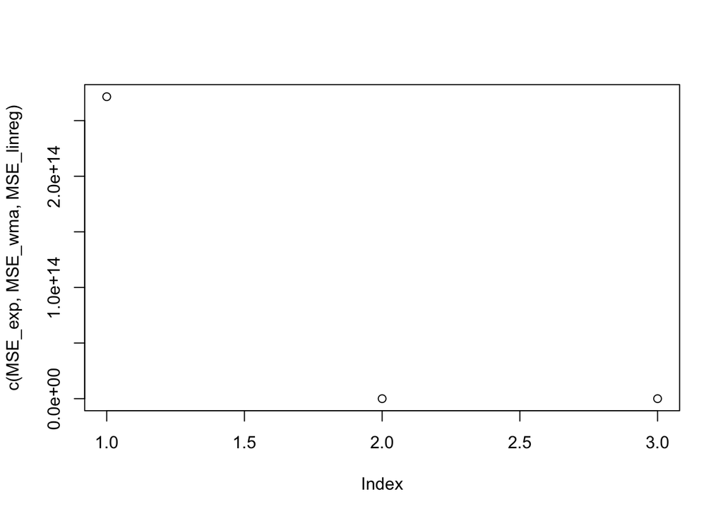

```r
plot(c(MSE_exp, MSE_wma, MSE_linreg)) # plotting the results
```

10. What is the ideal set of weights for the moving average model?

```r
# The model has the below equation:
# Yt = a*Y(t-1) + b*Y(t-2) + c*Y(t-3)
# a = 5 # weight for most recent year
# b = 3 # weight for second most recent year
# c = 2 # weight for third most recent year
dim <- 20

MSE_tracker <- array(dim = c(dim, dim, dim)) # creating an array to hold all MSE values
for (a in 1:dim) {
    for (b in 1:dim) {
        for (c in 1:dim) {
        pred2009 <- AvgPrice[1] # We'll artificially set the first "prediction" to match the actual
        pred2010 <- AvgPrice[1] # Model's prediction for 2010; same as 2009
        pred2011 <- (a * AvgPrice[2] + b * AvgPrice[1]) / (a + b) # Model's prediction for 2011
        preds <- c(pred2009, pred2010, pred2011,
                   sapply(2012:2016, wma)) # combining with predictions for 2012-2016
        MSE_tracker[a, b, c] <- sum(sapply(1:length(AvgPrice), diffSqr)) / length(AvgPrice) # calculateMSE
        }
    }
}
which.min(MSE_tracker) # determining index of the minimum MSE
```

```
## [1] 20
```

```r
MSE_tracker[which.min(MSE_tracker)] #outputting the minimum MSE
```

```
## [1] 116109013
```

Testing for all combinations of a, b, and c between 1 and 20 yielded that the best possible weighting was a = 20, b = 1, c = 1. We did not test for a,b,c = 0, but it makes sense that the best possible weighting would in fact be a = 1, b = 0, c = 0. We expect this result because the trend of SalePrice is consistently increasing. Therefore, a model which places maximum weight on the recent (and therefore greatest) value is closest to the next value. In practice, this means we should only look at the most recent value, ignoring all older values. Over a longer time period, where we don’t see a relatively constant upward trend in average sales price, a different weighting might make more sense.